# Inteligencia Artificial Generativa (AI Gen)

Universidad Austral

Clase 2: Agentes de código y la misión Corta

Autor: Paulo Veiga, Claudio Righetti y Marco Sánchez Sorondo  
Última modificación: Agosto 2026

01Agentes de código 02El repo como contexto 03El contrato de trabajo 04Skills y comandos 05Subagentes 06MCP servers 07Conclusiones 08La misión: Corta

01

Agentes de código

Agentes de código

## El problema: el trabajo que no es escribir código

1

El trabajo de desarrollo está lleno de tareas que no son escribir código nuevo: **entender un repo heredado**, ordenar, documentar, corregir bugs ajenos, migrar, deployar.

2

Hasta ahora la IA ayudaba a **tipear**: autocomplete, snippets, un chat al costado donde se pega un error.

3

Ninguna de esas herramientas **resuelve la tarea entera**: leer el proyecto, decidir, tocar archivos, verificar.

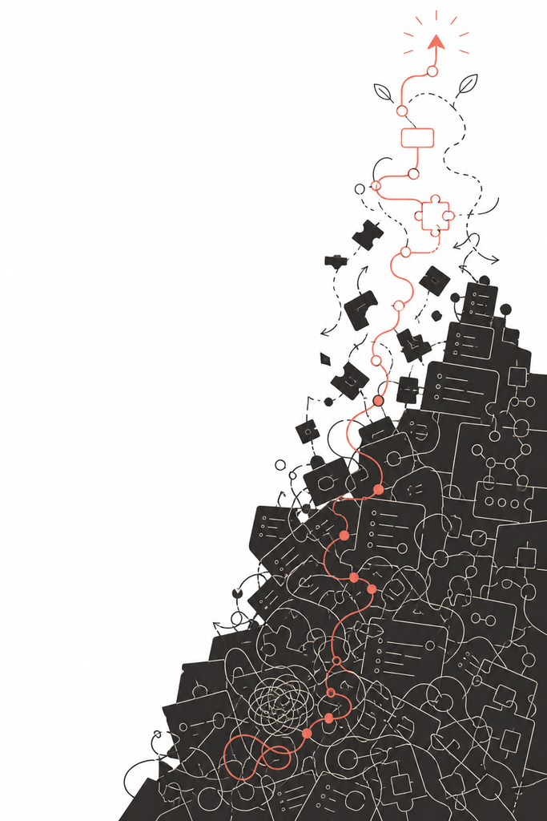

Agentes de código

## Agentes de código: Claude Code y Codex

**Agente de código**: Un programa que recibe una tarea en lenguaje natural, **planifica, edita archivos, corre comandos y verifica**, en un loop, hasta entregar.

### Claude Code (Anthropic)

CLI agéntico en la terminal; también con extensiones de IDE y app de escritorio.

### Codex (OpenAI)

El equivalente del otro lab; CLI y modo cloud.

### Misma familia que el chat que ya usan

**Mismos modelos por debajo, otra superficie**.

### La herramienta que prefieran

En esta materia pueden usar **la herramienta que prefieran**; la clase se demuestra con Claude Code.

Agentes de código

## Delegar una tarea completa

Cambia el **rol**. Autocompletar y chatear vs delegar:

Autocomplete / chatDelegar a un agente

La unidad de trabajoUna línea, un snippetUna tarea completa

Los pasosLos hace la personaEl agente planifica y ejecuta

La salidaTexto para copiar y pegarDiffs, commits, archivos, deploys

El rol humanoEscribir y pegarRevisar el plan y los diffs, corregir el rumbo

[figure not shown]

Agentes de código

## El mapa: piezas que se apilan

**Idea clave:** cada pieza resuelve un problema conocido y se apila sobre la anterior.

[figure not shown]

Agentes de código

## Dónde se empieza: pararse en una carpeta

1

Se instala el CLI y se abre **parado en la carpeta del proyecto**: `cd mi-proyecto/ && claude` (o `codex`).

2

El directorio de trabajo **define el alcance**: el agente ve ese árbol de archivos, no el resto del disco.

3

La primera interacción es una pregunta de reconocimiento: *"¿qué hay en este proyecto y en qué estado está?"*

4

El agente pide **aprobación** para acciones sensibles (editar, correr comandos); se puede ajustar cuánto pregunta.

01Agentes de código 02El repo como contexto 03El contrato de trabajo 04Skills y comandos 05Subagentes 06MCP servers 07Conclusiones 08La misión: Corta

02

El repo como contexto

El repo como contexto

## El modelo responde de memoria

- De fábrica, el modelo responde de su **memoria de entrenamiento**: una foto congelada hasta la fecha de corte. No conoce el proyecto.
- **In-context learning**: El modelo adapta su comportamiento con lo que ve en el prompt, sin reentrenarse. El contexto es **la única palanca**.
- Para un agente de código, la consecuencia es directa: **la calidad del resultado depende del contexto que le llega**, y ese contexto es el repo.

[figure not shown]

El repo como contexto

## Qué lee el agente al pararse en el repo

El agente **no carga el repo entero** en el contexto: lo explora con herramientas, como lo haría una persona.

1

#### Primero, el mapa

Árbol de archivos, README, configs (`package.json`, lockfiles), y la memoria del repo (CLAUDE.md / AGENTS.md, sección 3).

2

#### Después, búsqueda dirigida

Según la tarea: grep, lectura de archivos puntuales, historia de git, RAG.

**Consecuencia práctica**: **Un repo ordenado y con buenos nombres es un repo que el agente entiende mejor.** Lo mismo que le sirve a un humano nuevo en el equipo.

El repo como contexto

## Markdown, el formato del ecosistema

### El cerebro en Markdown

El contrato (`CLAUDE.md`), las Skills (`SKILL.md`) y los subagentes son archivos `.md`.

### Por qué

**Texto plano** que el modelo lee nativo, con marcas de estructura simples y un **frontmatter YAML** que declara qué es el archivo y cuándo usarlo.

### Entra en diffs, commits y PRs

**Como el código**: el mismo flujo de revisión vale para el conocimiento.

El repo como contexto

## El conocimiento del proyecto en .md

**La regla:** lo que el agente deba saber se guarda en **`.md` dentro del repo**: memoria, especificaciones y conocimiento en general.

### Memoria

Decisiones tomadas, estado de un trabajo largo, preferencias del equipo.

### Especificaciones

`SPEC.md`, el archivo donde se plasma con lujo de detalle lo que se espera del proyecto. El agente lo usa como guía, y de ahí se deriva la batería de tests (lámina 2.6).

### Conocimiento

Notas de arquitectura, hallazgos de una investigación, documentación de procesos.

El agente lo lee como contexto en cualquier sesión futura: **el conocimiento sobrevive a la conversación.** En una wiki externa o un formato opaco, el agente no lo ve.

El repo como contexto

## El manejo del contexto

### La ventana de contexto es finita

El objetivo: la ventana más chica posible con la máxima cantidad de información relevante.

### La ventana grande

Sostiene la visión de un repo entero y mucha información. El costo: **la performance del modelo puede empeorar**, y se **acumulan instrucciones contradictorias** sin que nadie lo recuerde.

### /compact

Resume la conversación en curso y libera ventana; lo importante sobrevive como resumen.

### La conexión con el .md

**Destilar el conocimiento a archivos** (CLAUDE.md, SPEC.md, notas) permite sesiones frescas con ventanas chicas.

**Contexto > prompting**: El buen desarrollo basado en IA se trata del buen manejo del contexto sobre el proyecto más que de los prompts.

El repo como contexto

## Iterar con el agente sobre el código

**Idea clave:** con un agente nada sale bien a la primera, y no hace falta. El trabajo son **vueltas chicas**: pedir, verificar, corregir el rumbo, volver a pedir.

### Los tests son la unidad de revisión principal

El diff se lee, pero lo que valida cada vuelta es la batería de tests.

### TDD, fuertemente recomendado

Una batería de tests bien grande, derivada de `SPEC.md`, escrita antes de implementar. El agente trabaja hasta que pasen.

### Cada vuelta es un pedido chico y verificable

*"Arreglá el redirect"*, *"agregá el test que lo cubre"*. Commits chicos y frecuentes hacen cada vuelta reversible.

### Partir la tarea en pedidos revisables

Pedidos gigantes ("hacé todo el proyecto") producen diffs imposibles de revisar.

01Agentes de código 02El repo como contexto 03El contrato de trabajo 04Skills y comandos 05Subagentes 06MCP servers 07Conclusiones 08La misión: Corta

03

El contrato de trabajo

El contrato de trabajo

## CLAUDE.md / AGENTS.md: la memoria del repo

Un archivo en la raíz del repo que el agente **lee automáticamente al arrancar cada sesión**: contexto e instrucciones permanentes del proyecto.

**CLAUDE.md** (Claude Code) y **AGENTS.md** (Codex y otros): mismo concepto, el contrato de trabajo del repo.

### Qué va ahí

- Cómo correr y testear el proyecto
- Convenciones del equipo
- Arquitectura en dos líneas
- **Reglas no negociables**

### Qué no va

- Nada que el código ya diga por sí solo
- Ni detalle que se desactualiza en una semana

Se versiona con git: **el contrato es del equipo entero** y le llega a cada sesión del agente.

El contrato de trabajo

## Un ejemplo de CLAUDE.md

**Nadie escribe esto a mano desde cero.** El agente lo genera de dos fuentes: **leyendo el repo** y **de las instrucciones explícitas del usuario** a medida que avanza la conversación.

Conviene **decirle lo más posible desde el principio**, y pedirle que **vaya recolectando en el CLAUDE.md** las preferencias e instrucciones que aparezcan. El trabajo humano: revisar que las reglas duras estén.

Markdown

```markdown
# CLAUDE.md, API de turnos del hospital
Servicio Node/Express + Postgres.

## Correr y testear
- `npm install && npm run dev` (puerto: variable PORT)
- Tests: `npm test`. Nada se commitea con tests rotos.

## Convenciones
- TypeScript estricto. Commits chicos, mensaje imperativo.

## Reglas no negociables
- NUNCA commitear secretos: credenciales en variables de entorno.
- No tocar legacy/ sin avisar: la mantiene otro equipo.
- Todo diff se revisa antes de commitear.
```

01Agentes de código 02El repo como contexto 03El contrato de trabajo 04Skills y comandos 05Subagentes 06MCP servers 07Conclusiones 08La misión: Corta

04

Skills y comandos

Skills y comandos

## Qué es una Skill

*"Todo lo que le explicás al agente más de una vez es una Skill que deberías escribir una vez."*

### Un instructivo en un archivo

Una carpeta con un `SKILL.md` (metadata YAML + pasos en prosa). No es código, aunque puede incluirlo.

### Se enseña una vez

Después la tarea sale siempre igual, mismos pasos, mismo formato de salida.

### Un trabajo por Skill

Si al describirla aparece un "y además", son dos.

**Ejemplo**: Una Skill `reporte-de-cambios` que lee los commits nuevos del repo y arma el reporte con el formato del equipo.

Skills y comandos

## Cómo se dispara una Skill

### Explícita

Se tipea `/` y se elige como comando: `/reporte-de-cambios`.

### Automática

Se pide la tarea en lenguaje natural (*"armame el reporte de esta semana"*) y el agente la carga porque el pedido coincide con su **descripción**.

La **description** es el disparador. Con una descripción vaga, la Skill nunca se activa sola.

El mismo principio vuelve en los subagentes (sección 5): **la descripción decide cuándo se usa la pieza.**

01Agentes de código 02El repo como contexto 03El contrato de trabajo 04Skills y comandos 05Subagentes 06MCP servers 07Conclusiones 08La misión: Corta

05

Subagentes

Subagentes

## Subagentes: varios trabajando a la vez

### Subagente

Asistente aislado, con **ventana de contexto propia**; devuelve un **resumen**, no la transcripción.

### Para qué

Sub-tareas pesadas o paralelas que generarían ruido en el contexto principal. Ejemplo: **auditar 6 módulos de un repo heredado**, un subagente por módulo, en paralelo.

### El agente principal

Reparte, espera y **consolida los resúmenes**.

### Pedir el trabajo en partes separables

Habilita el paralelo.

[figure not shown]

Subagentes

## Un subagente propio, por dentro

Un subagente propio es **un archivo `.md`**: frontmatter corto y las instrucciones en prosa.

La **description** vuelve a ser el disparador: decide cuándo el agente principal le delega.

En Claude Code van en **`.claude/agents/`** dentro del repo: se versionan con git, como el CLAUDE.md.

**Nadie lo escribe a mano**: se le pide al agente que lo genere y se revisa la descripción.

Markdown

```markdown
---
name: revisor-de-seguridad
description: Revisa un diff buscando secretos, credenciales y datos
  sensibles. Usar antes de cada commit importante.
tools: Read, Grep, Glob

---

Sos un revisor de seguridad. Para cada hallazgo: nombra el archivo
y la linea, explica el riesgo y propone la correccion.
```

01Agentes de código 02El repo como contexto 03El contrato de trabajo 04Skills y comandos 05Subagentes 06MCP servers 07Conclusiones 08La misión: Corta

06

MCP servers

MCP servers

## Qué es MCP

El trabajo real toca **sistemas externos**: GitHub, la base de datos, el deploy.

### MCP (Model Context Protocol)

El estándar abierto. Un **MCP server** expone las acciones de un servicio como **herramientas** que el agente llama.

### El mismo protocolo para todo

Se configura una vez por server y queda disponible.

[figure not shown]

MCP servers

## Cómo el agente descubre y usa una herramienta

1

Al conectar un server, el agente recibe el **catálogo de tools**: nombre, descripción y parámetros de cada una.

2

Ante una tarea, el agente **elige por descripción**: el mismo mecanismo que las Skills y los subagentes.

3

El catálogo dice **qué** hace cada tool. **Cuándo y cómo conviene usarla** lo dice la documentación del server.

**La práctica**: **Hacerle leer la documentación antes de usar.** *"Leé la documentación de este MCP y explicame qué herramientas expone y para qué las vas a usar acá."*

MCP servers

## El ecosistema MCP para desarrollo

Casi todo el toolchain de un equipo de desarrollo ya expone un MCP server:

### Versionado y code review

GitHub, GitLab

### Bases de datos

Postgres, MySQL, MongoDB, Supabase

### Browsers y testing E2E

Playwright, Chrome DevTools

### Observabilidad y errores

Sentry, Grafana

### Gestión de proyectos

Jira, Linear, Slack

### Diseño

Figma

### Documentación de librerías

Context7

### Infraestructura y deploy

Railway, AWS, Cloudflare

El patrón es siempre el mismo: **el server expone tools, el agente las descubre y las usa.** Aprendido una vez, vale para todos.

Con esto, el agente **opera el ciclo completo de desarrollo**, mucho más que el repo.

MCP servers

## Dónde buscar servidores MCP publicados

FuenteQué encontrás

Directorio de conectores de Claude (Anthropic)El catálogo oficial del proveedor del agente; conectores verificados

Apps y conectores de ChatGPT (OpenAI)El equivalente oficial del otro lab

github.com/modelcontextprotocol/serversRepo de referencia mantenido por la comunidad y Anthropic

PulseMCP (pulsemcp.com)Directorio curado, marca cuáles son oficiales del proveedor

Smithery (smithery.ai)Marketplace de servidores MCP, instalación asistida

Glama (glama.ai/mcp/servers)Directorio con ranking y metadata de cada servidor

mcp.soListado comunitario amplio

**Criterio antes de conectar uno**: Mirar **quién lo publica**. Un MCP server corre con las credenciales del usuario.

01Agentes de código 02El repo como contexto 03El contrato de trabajo 04Skills y comandos 05Subagentes 06MCP servers 07Conclusiones 08La misión: Corta

07

Conclusiones

Conclusiones

## El nuevo rol: Diseñar, delegar y revisar

### Las piezas

El repo como contexto, CLAUDE.md como contrato, Skills y subagentes para reusar, MCP para las herramientas externas.

### Todo es archivos versionados en el repo

El contrato, las Skills, los subagentes. El equipo los hereda con un clone.

### Para esta semana

La misión Corta. Todo lo de hoy se usa ahí.

Conclusiones

## Antes de cerrar: cuidados

### El agente se equivoca con confianza

Código que compila y está mal, tests que pasan por casualidad, explicaciones seguras y falsas. **Todo diff se lee antes de aceptar.**

### Secretos fuera del código y fuera del contexto

Credenciales en variables de entorno, nunca en el repo ni en un `.txt`. Lo que el agente lee puede terminar en un commit.

### Contenido externo es contexto no confiable (prompt injection)

Un README ajeno, una página o un issue pueden traer instrucciones que el agente lea como si vinieran del usuario.

### Capas de guardarraíles

Alcance de la carpeta, reglas en CLAUDE.md, aprobación de acciones, revisión humana del diff.

01Agentes de código 02El repo como contexto 03El contrato de trabajo 04Skills y comandos 05Subagentes 06MCP servers 07Conclusiones 08La misión: Corta

08

La misión: Corta

La misión: Corta

## La historia de Corta

Se suman al equipo de una empresa. El dev anterior **se fue hace un mes sin dejar documentación**, y era el dueño de **Corta**, el acortador de URLs interno.

### Lo que entregó

**Una carpeta copiada de su computadora**. Sin git, sin README, con duplicados, versiones viejas, notas sueltas, y una app que "más o menos anda": `server_OLD.js` · `index_v2_FINAL.js` · `links_backup_marzo.json` · `notas.txt` · `Nueva carpeta` ...

### El trabajo

**Llevar Corta a producción**, con historia completa en GitHub desde el estado en que la recibieron.

### Las herramientas

Su agente + dos MCP servers. **GitHub MCP** (github.com/github/github-mcp-server) para versionado y repo remoto; **Railway MCP** (docs.railway.com/ai/mcp-server) para infraestructura, deploy y **provisionar la base de datos**. Requisitos: cuenta de GitHub y cuenta gratuita de Railway.

### Paso 0 obligatorio

**Pararse en `corta/`, configurar los dos MCPs, y hacerle leer al agente la documentación de ambos** (criterio: que pueda explicar qué herramientas expone cada uno y para qué las va a usar).

### Corta no tiene specs escritas

El dueño tenía ese conocimiento en la cabeza. Escribir el `SPEC.md` (y la batería de tests que se deriva) **es parte del ejercicio**.

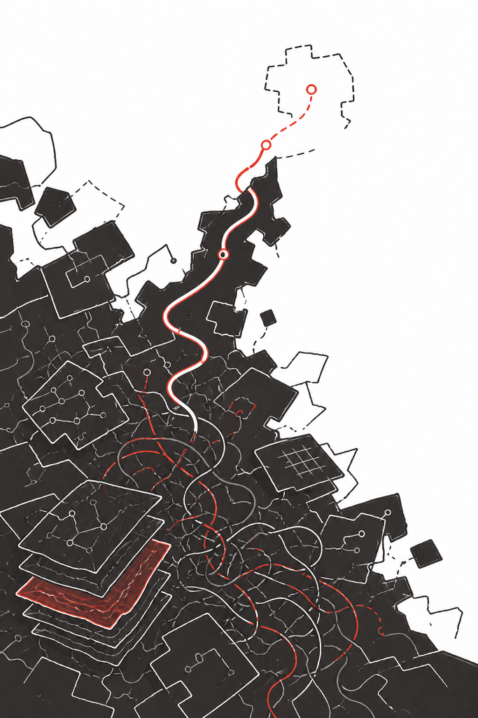

La misión: Corta

## La misión: del caos a producción

**La forma de trabajo:** `SPEC.md` (lo que se espera de Corta, con detalle) + **TDD**: la batería de tests se deriva del SPEC, se escribe antes y corre verde en cada milestone.

1

#### Trackear

Repo en GitHub vía MCP; el desorden inicial se pushea **tal cual**, primer commit.

2

#### Ordenar

3

#### Corregir los errores

Usen la app: ahí están las pistas.

4

#### Completar stats

Endpoint + `stats.html`.

5

#### Producción

Deploy en Railway vía MCP. La pregunta que va a aparecer sola: **¿dónde viven los datos?** La prueba de fuego: sobreviven a un redeploy.

6

#### Extra de equipo

Todos colaboradores en el repo + una **tarea programada** por integrante que actualiza desde el remote y reporta los cambios.

7

#### Extra de memoria

Una Skill **`/collect-memory`** que actualiza la memoria y las instrucciones del agente (`CLAUDE.md` / `AGENTS.md`) con los avances de la conversación y las preferencias expresadas por el equipo.

**Entrega**: La URL pública + el link al repo con la historia completa.

[figure not shown]